# stats_practice

Nicole Jimenez

2022-10-26

```r
##set up libraries
library(dplyr)
library(tidyverse)
library(caret)
```

```r
library(readr)
library(ggplot2)
library(data.table)
```

Load Data

```r
##load feature data - species
Cer_vaginal_species_feature <-
  read_csv("C:/Users/nicolejimenez/OneDrive - University of Arizona/Desktop/Atopobium/cervical_cancer_NAU/cervical_cancer_NAU_level_7_taxa_table.csv")
View(Cer_vaginal_species_feature)
```

```r
#load metadata check to make sure it is csv not txt!
Cer_AV_vag_meta <- read_csv("C:/Users/nicolejimenez/OneDrive - University of Arizona/Desktop/Atopobium/cervical_cancer_NAU/Cervical_cancer_NAU_metadata_level_7.csv")
View(Cer_AV_vag_meta)
```

Statistical Question: Does the number of Atopobiaceae species types affect the genital inflammatory score?

Null hypothesis: The number of Atopobiaceae species types does not affect genital inflammatory score Alternate hypothesis: the number of Atopobiacea species types does affect the genital inflammatory score

```r
model <- lm(T_infl_score_flt ~ Atopobiaceae_types, data = Cer_AV_vag_meta)
summary(model)$coef
```

```
##                     Estimate Std. Error  t value    Pr(>|t|)
## (Intercept)        1.3686552  0.3029662 4.517517 0.000017815
## Atopobiaceae_types 0.2847985  0.1589580 1.791660 0.076338322
```

genital inflammation = 1.369 + 0.284*Atopobiaceae_species

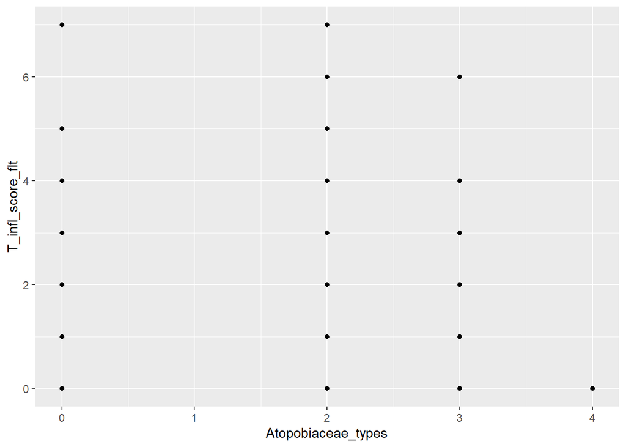

```r
ggplot(Cer_AV_vag_meta, aes(x = Atopobiaceae_types, y = T_infl_score_flt)) +
  geom_point() +
  stat_smooth()
```

Since the data is in groups there is no correlation observed, let’s try with more true continous variables… The null hypothesis is not rejected.

New Statistical Question: Does the number of BMI affect the genital inflammatory score?

Null hypothesis: The number of BMI does not affect genital inflammatory score Alternate hypothesis: the number of BMI does affect the genital inflammatory score

```r
model <- lm(T_infl_score_flt ~ F_pcov_BMI, data = Cer_AV_vag_meta)
summary(model)$coef
```

```
##                Estimate Std. Error   t value     Pr(>|t|)
## (Intercept)  3.35602759 0.76199269  4.404278 2.783624e-05
## F_pcov_BMI  -0.05263448 0.02476899 -2.125016 3.618035e-02
```

genital inflammation = 3.356 - 0.052*BMI

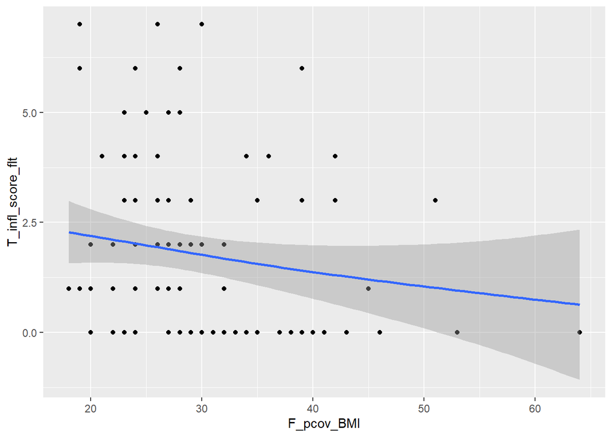

```r
ggplot(Cer_AV_vag_meta, aes(x = F_pcov_BMI
, y = T_infl_score_flt)) +
  geom_point() +
  stat_smooth()
```

In this dataset there is a weak negative correlation observed with genital inflammation score. Meaning women with higher BMI tend to have lower genital inflammation which is counter-intuitive since obesity is associated with systemic inflammation. That said the inflammation level is a score an not based on a true continous variable such as inflammatory cytokine levels. The null hypothesis is rejected.